# BIO8102 term project: The effect of Bti on soil microbiome in Kanata, Ontario, Canada

Rui Zhang

3/26/2021

*data used in this project can be found in my github repository: (https://github.com/Rui-Zzhang/BIO8102-Term-Project)

## 1 Introduction (10%)

### 1.1 Background

*Bacillus thuringiensis subsp. israelensis* (Bti) is a biolarvicde that is widely used in Europe and North America for mosquito control, due to its reputation of being an effective, environmentally-friendly and mosquito-specific biocide Despres, Lagneau, and Frutos (2011). As a bio-larvicide, the toxicity of Bti to mosquito larvae is associated with its Cry and Cyt toxins produced as crystals during bacterial sporulation, which are solubilized in the gut of the mosquito larvae after ingestion Ben-Dov (2014). The toxins can then bind to certain protein receptors on the gut cell membrane, leading to the oligomerization and disruption of the gut, which ultimately cause the larval death Vachon, Laprade, and Schwartz (2012). The specificity of this toxin makes it an ideal larvicide to control larvae of the suborder Nematocera, which includes mosquitoes, black flies and chironomids Brühl et al. (2020).

For the above benefits, the City of Ottawa initiated a pilot project to investigate the effect of Bti on eliminating the local mosquito population in Kanata in response to increased complains from local residents about mosquito nuisance. The bio-larvicide was applied for three years in South March Highlands Conservation Forest (SMHCF) from 2016 to 2018. With the close monitoring of its effects on mosquito populations, the University of Ottawa MSc student Liam Epp collected data about the number of mosquitos in the Bti treated and control sites, along with the sediments from those area. His study concluded that statistical modelling failed to show Bti treatment as a significant predictor of mosquito quantities Epp (2018).

### 1.2 Study system and hypothese

As one of the drivers for biogeochemical cycling of various nutrient and other elements, soil microbiomes are essential for the survival and prosperity of plants and animal life Jansson and Hofmockel (2020). Following the lack of evidence of Bti as an effective bio-larvicide in reducing mosquito populations in Kanata, we thus wondered whether Bti can affect the local soil microbiocidal communities and alter their structures.

Bacillus thuringiensis (or Bt) is a Gram-positive, facultative anaerobic endospore-forming bacterium that is commonly found in soil as well as estuarine sediments. It can also be found naturally on leaf surfaces, aquatic environments, animal feces and insect-rich environment (ref: brock biology of microorganisms). Due to its soil-dwelling property, **we hypothesize that its application would alter the soil microbial structures, thus result in a change in microbial diversity as well as relative abundance.**

## 2 Methods (20%)

### 2.1 Data collection

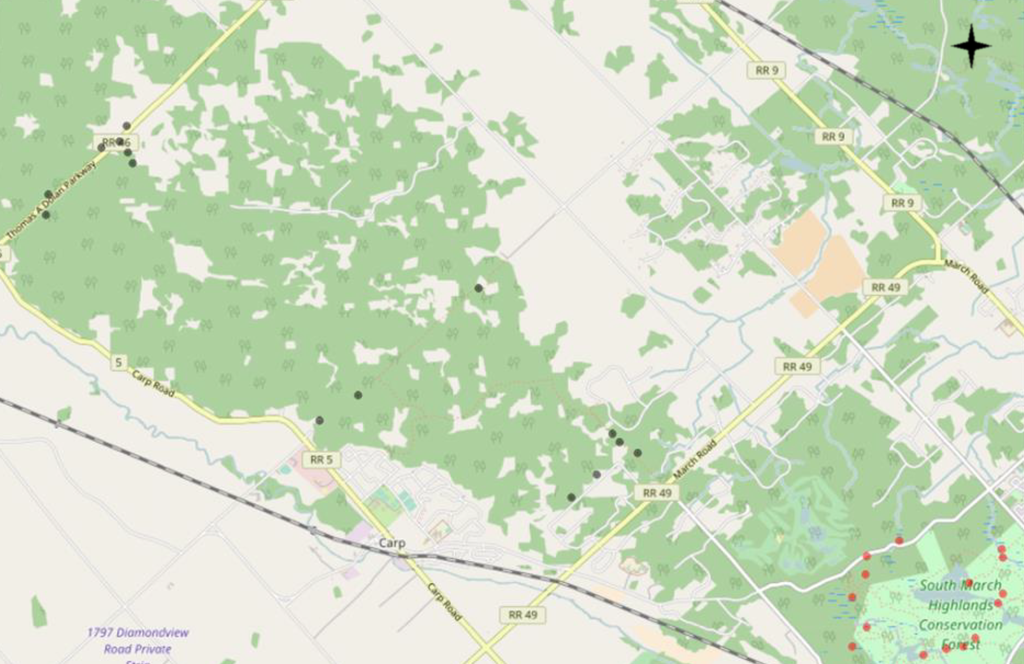

Soil samples were collected near water ponds, then pH, Conductivity (uS), temperature (deg Celsius) and dissolved oxygen (DO) (mg/L), as well as the concentration of ammonia (mg/L) and nitrate(mg/L) were recorded along with the soil samples. Soil samples then subsequently underwent DNA extract and sent to a sequencing facility for 16S rRNA sequencing. The samples were processed and analyzed using the Quantitative Insights into Microbial Ecology (QIIME2, version 2020.8) Bolyen et al. (2019) custom pipeline. Alpha diversity metrics were obtained, which are measures of species diversity within a sample. Here we obtained three alpha diversity metrics generated by QIIME2 including Shannon’s diversity index, Pielou’s Evenness and Faith’s Phylogenetic Diversity, which are all continuous real numbers.

### 2.2 Statistical approach

In this project, we will be mainly examining the effect of Bti treatment on these three-alpha diversity metrices by accounting for the physical chemical parameters as well as week and year using various statistical approach.

#### 2.2.1 General linear mixed model

Loading relevant packages

```r
library(lme4)
library(tidyverse)
library(patchwork)
library(lattice)
```

Let’s inspect the data first. Please note that the `TreatP` column shows if a site is desginated as a bti-treated site or a control site without any treatment. `BTI` represents the treatment sites and `CTRL` represents the control sites.

```r
kanata_data <- read.csv("BIO8102_bti_metadata.csv")
str(kanata_data)
```

```
## 'data.frame':    143 obs. of  18 variables:
##  $ SampleID       : chr  "April-1-2017" "April-10-2017" "April-2-2017" "April-3-2017" ...
##  $ Site           : int  1 2 3 4 8 10 11 12 13 14 ...
##  $ Long           : num  -75.9 -75.9 -76 -75.9 -76 ...
##  $ Lat            : num  45.3 45.3 45.3 45.3 45.3 ...
##  $ AreaName       : chr  "South_March_Highlands_Conservation_Forest" "South_March_Highlands_Conservation_Forest" "South_March_Highlands_Conservation_Forest" "South_March_Highlands_Conservation_Forest" ...
##  $ DO             : chr  "7.25" "9.37" "7.36" "7.14" ...
##  $ pH             : num  7.44 7.8 7.7 7.1 8.4 7.43 6.84 7.6 7.77 7.28 ...
##  $ conductivity   : num  199 230 159 157 120 ...
##  $ water_temp     : num  14.3 14.8 14.4 14.5 14.5 5.4 6.3 6.1 10.5 6.6 ...
##  $ ammonia        : num  0 0.03 0.02 0.01 0.02 0.01 0.01 0.04 0.06 0.03 ...
##  $ nitrate        : num  0.46 0.32 0.33 0.34 0.23 0.28 0.19 0.26 0.41 0.37 ...
##  $ TreatP         : chr  "BTI" "BTI" "BTI" "BTI" ...
##  $ shannon_entropy: num  9.91 9.39 9.45 9.75 9.32 ...
##  $ pielou_evenness: num  0.929 0.911 0.909 0.922 0.917 ...
##  $ faith_pd       : num  95.7 92.9 96 106.9 70.1 ...
##  $ Week           : int  16 16 16 16 16 17 17 17 17 17 ...
##  $ Date           : chr  "2016/4/22" "2016/4/22" "2016/4/22" "2016/4/22" ...
##  $ Year           : int  2016 2016 2016 2016 2016 2016 2016 2016 2016 2016 ...
```

Let’s we convert `Week`, `Year` and `TreatP` into factors.

```r
kanata_data <- mutate(
  kanata_data,
  Week = factor(Week),
  Year = factor(Year),
  TreatP = factor(TreatP))
```

Now, let’s check the replications of each categories in our datasite.

```r
# check replication for each `Week` within each treatment type `TreatP`.
(reptab <- with(kanata_data, table(TreatP, Week)))
```

```
##       Week
## TreatP 16 17 18 19 20 21 22 23 25
##   BTI   5 13 14  7  7 13  7  7  7
##   CTRL  0 12  6 11  6 10  6  6  6
```

```r
# check replication for each `Site` within each treatment type `TreatP`
(reptab <- with(kanata_data, table(TreatP, Site)))
```

```
##       Site
## TreatP  1  2  3  4  6  8  9 10 11 12 13 14 15 16 18 19 20 23 24 25 28 30
##   BTI  10  1  1 11 10  1 10  1  1 11  1 11 11  0  0  0  0  0  0  0  0  0
##   CTRL  0  0  0  0  0  0  0  0  0  0  0  0  0  1  1 11  8 10  9  1 11 11
```

```r
# check replication for each `Site` within each treatment type `TreatP`
(reptab <- with(kanata_data, table(TreatP, Year)))
```

```
##       Year
## TreatP 2016 2017 2018
##   BTI    11   34   35
##   CTRL    6   27   30
```

```r
  # Here for 2016 data, the number of replications for BTI and CTRL are much less than that of 2017, 2018 due to insufficient sampling efforts in that year. Let's try to remove 2016 data.

kanata_data_filtered <- subset(kanata_data, Year!="2016")
```

Let’s start with an initial plot of the alpha diversity metrics against treatment types.

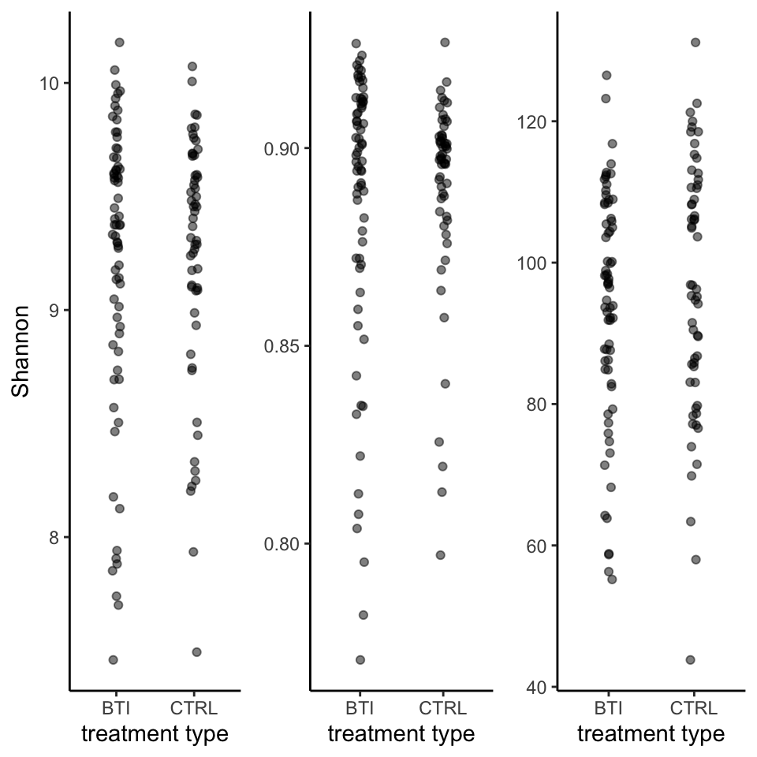

Just by visualizing the plots, it seems that Bti treatment did not create much differences in terms of the three metrics.

Let’s try to fit a liner mixed models with TreatP and year as fixed effect, sites as a random effect intercept, (i.e., since each site was measured repeatedly). Here I am only going to use Shannon diversity since the distributions of the three metrics look pretty similar.

```r
m1_1 <- lmer(shannon_entropy ~ TreatP + Year + (1 | Site), data = kanata_data_filtered)
summary(m1_1)
```

```
## Linear mixed model fit by REML ['lmerMod']
## Formula: shannon_entropy ~ TreatP + Year + (1 | Site)
##    Data: kanata_data_filtered
##
## REML criterion at convergence: 233.1
##
## Scaled residuals:
##     Min      1Q  Median      3Q     Max
## -2.6305 -0.3720  0.2212  0.6497  2.0182
##
## Random effects:
##  Groups   Name        Variance Std.Dev.
##  Site     (Intercept) 0.06217  0.2493
##  Residual             0.32236  0.5678
## Number of obs: 126, groups:  Site, 13
##
## Fixed effects:
##             Estimate Std. Error t value
## (Intercept)  9.14263    0.12730  71.819
## TreatPCTRL   0.02607    0.17206   0.152
## Year2018     0.10859    0.10137   1.071
##
## Correlation of Fixed Effects:
##            (Intr) TPCTRL
## TreatPCTRL -0.614
## Year2018   -0.404 -0.012
```

```r
confint(m1_1)
```

```
## Computing profile confidence intervals ...
```

```
##                   2.5 %    97.5 %
## .sig01       0.07094985 0.4042184
## .sigma       0.49888711 0.6482195
## (Intercept)  8.89670420 9.3873075
## TreatPCTRL  -0.30861606 0.3602459
## Year2018    -0.09275806 0.3065827
```

## 3 Results (25%)

## 4 Discussion (15%)

## Style (30%)

- clarity and code reproducibility (10%)
- organization (5%)
- clarity of text (10%)
- Typos and grammar (5%)

## 5 Reference

Ben-Dov, Eitan. 2014. “Bacillus Thuringiensis Subsp. Israelensis and Its Dipteran-Specific Toxins.” *Toxins* 6 (4): 1222–43. https://doi.org/10.3390/toxins6041222.

Bolyen, Evan, Jai Ram Rideout, Matthew R. Dillon, Nicholas A. Bokulich, Christian C. Abnet, Gabriel A. Al-Ghalith, Harriet Alexander, et al. 2019. “Reproducible, Interactive, Scalable and Extensible Microbiome Data Science Using QIIME 2.” *Nature Biotechnology* 37 (8): 852–57. https://doi.org/10.1038/s41587-019-0209-9.

Brühl, Carsten A., Laurence Després, Oliver Frör, Chandrashekhar D. Patil, Brigitte Poulin, Guillaume Tetreau, and Stefanie Allgeier. 2020. “Environmental and Socioeconomic Effects of Mosquito Control in Europe Using the Biocide Bacillus Thuringiensis Subsp. Israelensis (Bti).” *Science of the Total Environment* 724 (July): 137800. https://doi.org/10.1016/j.scitotenv.2020.137800.

Despres, L., C. Lagneau, and R. Frutos. 2011. “Using the Bio-Insecticide Bacillus Thuringiensis Israelensis in Mosquito Control.” *Pesticides in the Modern World*, 2011.

Epp, Liam. 2018. “Effect of Biolarvicide, Bacillus Thuringiensis Var. Israelensis on Chironomidae in the South,” 45. https://doi.org/https://kanatanorth.ca/wp-content/uploads/2019/05/KANATA-Chironomidae-Bti-Report-2018.pdf.

Jansson, Janet K., and Kirsten S. Hofmockel. 2020. “Soil Microbiomes and Climate Change.” *Nature Reviews Microbiology* 18 (1): 35–46. https://doi.org/10.1038/s41579-019-0265-7.

Vachon, Vincent, Raynald Laprade, and Jean-Louis Schwartz. 2012. “Current Models of the Mode of Action of Bacillus Thuringiensis Insecticidal Crystal Proteins: A Critical Review.” *Journal of Invertebrate Pathology* 111 (1): 1–12. https://doi.org/10.1016/j.jip.2012.05.001.